# Self-Driving Car Engineer Nanodegree

## Project: Build a Traffic Sign Recognition Classifier

The goal of this project is to design and implement the convolutional neural networks for traffic signs recognition.  
Built model is trained on images from the German Traffic Sign Database.

## Step 0: Load The Data

```python
# Load pickled data
import pickle

training_file = 'traffic-signs-data/train.p'
validation_file= 'traffic-signs-data/valid.p'
testing_file = 'traffic-signs-data/test.p'

with open(training_file, mode='rb') as f:
    train = pickle.load(f)
with open(validation_file, mode='rb') as f:
    valid = pickle.load(f)
with open(testing_file, mode='rb') as f:
    test = pickle.load(f)

X_train, y_train = train['features'], train['labels']
X_valid, y_valid = valid['features'], valid['labels']
X_test, y_test = test['features'], test['labels']
```

```python
from sklearn.utils import shuffle
import pickle

training_file = 'traffic-signs-data/train_extended.p'

with open(training_file, mode='rb') as f:
    train = pickle.load(f)

X_train, y_train = train['features'], train['labels']

X_train, y_train = shuffle(X_train, y_train)
```

## Step 1: Dataset Summary & Exploration

The pickled data is a dictionary with 4 key/value pairs:

- `'features'` is a 4D array containing raw pixel data of the traffic sign images, (num examples, width, height, channels).
- `'labels'` is a 1D array containing the label/class id of the traffic sign. The file `signnames.csv` contains id -> name mappings for each id.
- `'sizes'` is a list containing tuples, (width, height) representing the original width and height the image.
- `'coords'` is a list containing tuples, (x1, y1, x2, y2) representing coordinates of a bounding box around the sign in the image. **THESE COORDINATES ASSUME THE ORIGINAL IMAGE. THE PICKLED DATA CONTAINS RESIZED VERSIONS (32 by 32) OF THESE IMAGES**

### Provide a Basic Summary of the Data Set

```python
import numpy as np

# Number of training examples
n_train = y_train.size

# Number of validation examples
n_validation = y_valid.size

# Number of testing examples.
n_test = y_test.size

# TODO: What's the shape of an traffic sign image?
image_shape = (X_train.shape[1], X_train.shape[2]) # width, height

# How many unique classes/labels there are in the dataset.
labels = np.unique(np.concatenate((y_train, y_valid, y_test)))
n_classes = labels.shape[0]

print("Number of training examples =", n_train)
print("Number of testing examples =", n_test)
print("Image data shape =", image_shape)
print("Number of classes =", n_classes)
```

```
Number of training examples = 51448
Number of testing examples = 12630
Image data shape = (32, 32)
Number of classes = 43
```

### Include an exploratory visualization of the dataset

```python
# Write down classes names and corresponding indices

import pandas as pd

print(pd.read_csv('signnames.csv'))
```

```
    ClassId                                           SignName
0         0                               Speed limit (20km/h)
1         1                               Speed limit (30km/h)
2         2                               Speed limit (50km/h)
3         3                               Speed limit (60km/h)
4         4                               Speed limit (70km/h)
5         5                               Speed limit (80km/h)
6         6                        End of speed limit (80km/h)
7         7                              Speed limit (100km/h)
8         8                              Speed limit (120km/h)
9         9                                         No passing
10       10       No passing for vehicles over 3.5 metric tons
11       11              Right-of-way at the next intersection
12       12                                      Priority road
13       13                                              Yield
```

[output cut: 29 more lines]

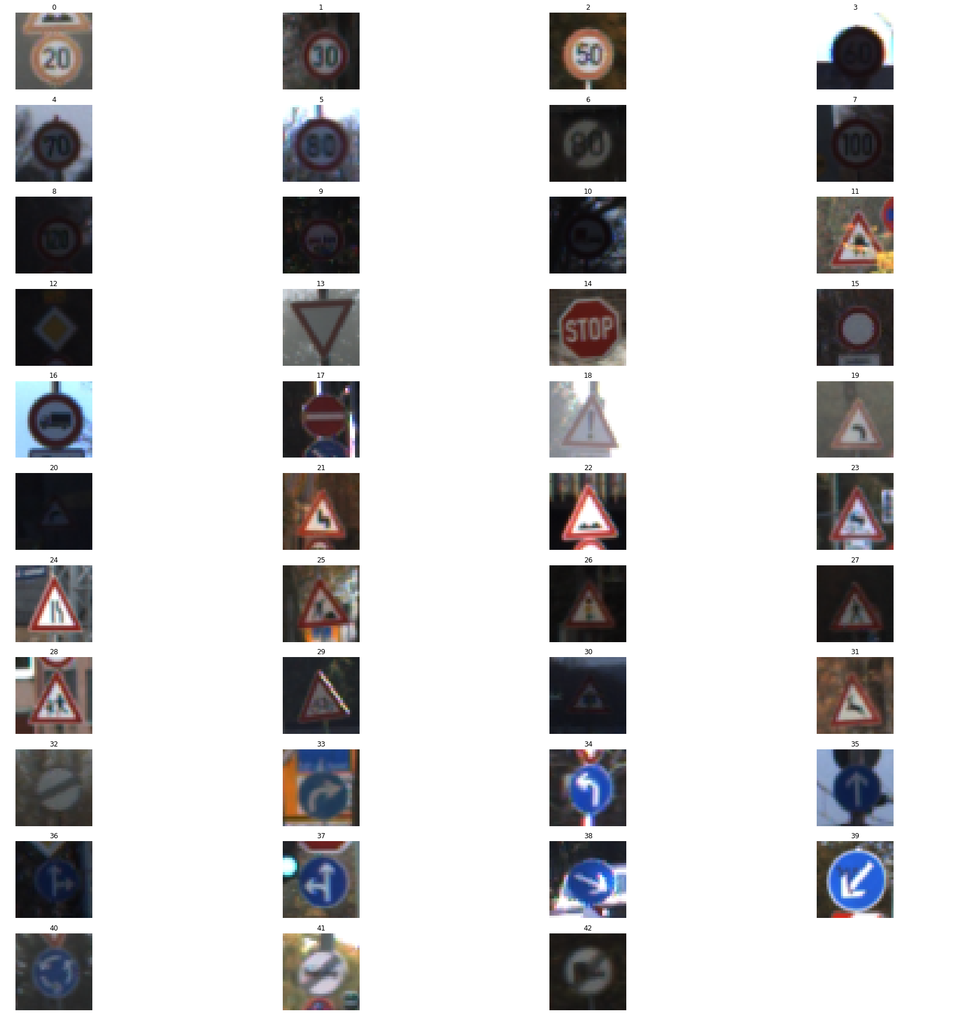

```python
# Visualize images from training set

import cv2
import matplotlib.pyplot as plt
import math
import matplotlib.pyplot as plt
# Visualizations will be shown in the notebook.
%matplotlib inline

image_examples = []

n = 11
fig, axes = plt.subplots(
ncols=math.ceil(n_classes/n),
nrows=n,
figsize=(32, 32))

axes = axes.ravel()

for i in range(n_classes):
    idx = np.where(y_train == i)
    image_examples.append(X_train[idx][100])
    axes[i].imshow(X_train[idx][100])
    axes[i].set_title(str(i))

for ax in axes:
    ax.axis('off')

plt.show()
```

[figure not shown]

```python
# Plot classes distribution in training, validation and testing sets

import matplotlib.pyplot as plt
# Visualizations will be shown in the notebook.
%matplotlib inline

binwidth = 1

fig, ((ax1, ax2, ax3)) = plt.subplots(
    ncols=3,
    nrows=1,
    figsize=(20, 10))

ax1.set_title('Train')
(count_train, bins_train, patches_train) = ax1.hist(y_train, bins=range(0, n_classes + binwidth, binwidth))

ax2.set_title('Validation')
ax2.hist(y_valid, bins=range(0, n_classes + binwidth, binwidth))

ax3.set_title('Testing')
ax3.hist(y_test, bins=range(0, n_classes + binwidth, binwidth))

plt.show()
```

## Step 2: Design and Test a Model Architecture

Design and implement a deep learning model that learns to recognize traffic signs. Train and test your model on the [German Traffic Sign Dataset](http://benchmark.ini.rub.de/?section=gtsrb&subsection=dataset).

The LeNet-5 implementation shown in the classroom at the end of the CNN lesson is a solid starting point. You'll have to change the number of classes and possibly the preprocessing, but aside from that it's plug and play!

With the LeNet-5 solution from the lecture, you should expect a validation set accuracy of about 0.89. To meet specifications, the validation set accuracy will need to be at least 0.93. It is possible to get an even higher accuracy, but 0.93 is the minimum for a successful project submission.

There are various aspects to consider when thinking about this problem:

- Neural network architecture (is the network over or underfitting?)
- Play around preprocessing techniques (normalization, rgb to grayscale, etc)
- Number of examples per label (some have more than others).
- Generate fake data.

Here is an example of a [published baseline model on this problem](http://yann.lecun.com/exdb/publis/pdf/sermanet-ijcnn-11.pdf). It's not required to be familiar with the approach used in the paper but, it's good practice to try to read papers like these.

### Generate fake data

If the amount of class samples is less than mean value. Then for every sample in this class several new samples will be generated to fill the gap between original and mean numbers.  
Two ways of transformation were implemented. First, rotate image by random angle in range ±10. Then translate this image.  
Second method applyes affine tranformaion by randomly choosing source and destination points.  
In both cases the image brightness can be also changed.

```python
import cv2
import math

def get_random_rotate_matrix(img):
    angle_range_deg = 10
    angle_deg = np.random.uniform(-angle_range_deg,angle_range_deg)
    angle = np.deg2rad(angle_deg)
    (h, w) = img.shape[:2]
    (cX, cY) = (w // 2, h // 2)
    return np.float32([[math.cos(angle),    -math.sin(angle),    0.0],
                       [math.sin(angle),    math.cos(angle),     0.0],
                       [0.0,                  0.0,               1.0]])

def get_random_translate_matrix(img):
    t_range = 5
    t_x = np.random.uniform(0,t_range)
    t_y = np.random.uniform(0,t_range)
    return np.float32([[1,0,t_x],[0,1,t_y],[0,0,1]])

def blur_img(img):
    kernel_size = np.random.randint(0, 3)*2+1
    if kernel_size == 1:
        return img
    return cv2.GaussianBlur(img,(kernel_size,kernel_size),0)

def change_brightness(img):
    hsvImg = cv2.cvtColor(img,cv2.COLOR_BGR2HSV)
    alpha = np.random.uniform(0.4, 1)
    hsvImg[...,2] = hsvImg[...,2]*alpha
    return cv2.cvtColor(hsvImg, cv2.COLOR_HSV2BGR)

def transform_affine(img):
    shift = []
    (cols,rows) = img.shape[:2]
    for i in range(7):
        shift.append(np.random.randint(0, 4))
    d1 = shift[0]
    pts1 = np.float32([[d1,d1],[cols-d1,d1],[d1,rows-d1]])
    pts2 = np.float32([[d1+shift[1],d1+shift[2]],[cols-d1-shift[3],d1-shift[4]],[d1+shift[5],rows-d1-shift[6]]])
    M = cv2.getAffineTransform(pts1,pts2)
    return cv2.warpAffine(img,M,(cols,rows))

def transform(img):
    '''Main function.
       Here the transformation method is randomly chosen.
       '''
    switch = np.random.randint(0, 2)
    if switch==0:
        R = get_random_rotate_matrix(img)
        T = get_random_translate_matrix(img)
        M = np.matmul(R, T)
        M = M[0:2, :]
        (h, w) = img.shape[:2]
        dst = cv2.warpAffine(img,M,(h, w), flags=cv2.INTER_LINEAR)
    else:
        dst = transform_affine(img)
    blur = blur_img(dst)
    return change_brightness(blur)
```

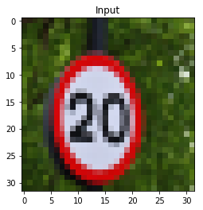

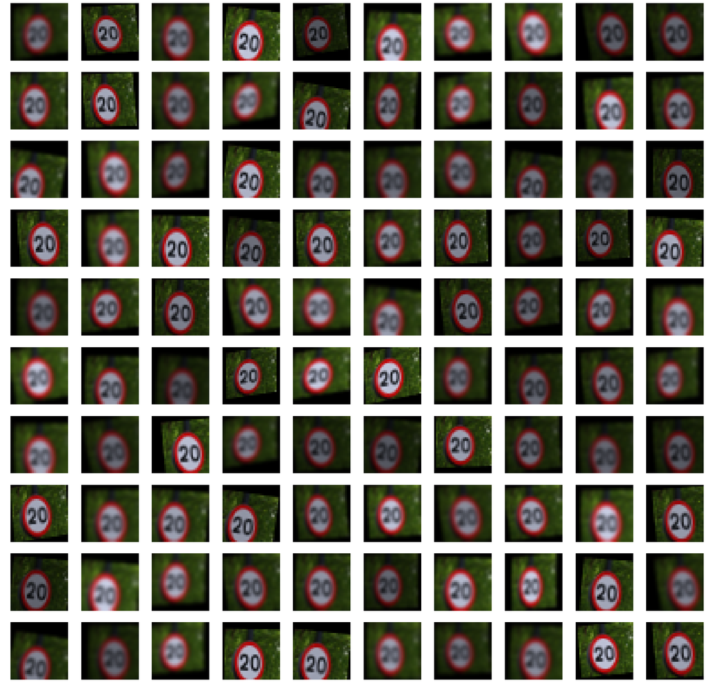

```python
image_name = 'test_images/20.jpg'
img = cv2.imread(image_name)
resized_img = cv2.resize(img, (32,32), interpolation=cv2.INTER_AREA)

plt.imshow(cv2.cvtColor(resized_img, cv2.COLOR_BGR2RGB))
plt.title('Input')
plt.show()

fig, axes = plt.subplots(
ncols=10,
nrows=10,
figsize=(32, 32))

axes = axes.ravel()

for ax in axes:
    ax.imshow(cv2.cvtColor(transform(resized_img), cv2.COLOR_BGR2RGB))
    ax.axis('off')

plt.show()
```

```python
def generate_images(img, N):
    add_images = []
    for i in range(N):
        add_images.append(transform(img))
    add_images = np.array(add_images)
    return add_images
```

```python
min_count = np.mean(count_train) #calculated at 'histogram' step
for num in range(n_classes):
    class_idxs = np.where(num == y_train)
    samples_count = len(class_idxs[0])
    if samples_count < min_count:
        samples_to_add = math.ceil((min_count - samples_count) / samples_count)
        if samples_to_add == 0:
            continue
        print("For class %d generate %d new images based on each image. Total %d." % (num, samples_to_add, samples_to_add*samples_count))
        for i in class_idxs[0]:
            add_imgs = generate_images(X_train[i], samples_to_add)
            X_train = np.concatenate((X_train, add_imgs), axis=0)
            add_labels = num*np.ones(samples_to_add)
            y_train = np.concatenate((y_train, add_labels), axis=0)

# save extended train data
train_extended_file = "traffic-signs-data/train_extended.p"
file = open(train_extended_file, 'wb')

train_dict = {'features': 1, 'labels': 2}
train_dict['features'] = X_train
train_dict['labels'] = y_train
pickle.dump(train_dict, file)
file.close()
```

```
For class 0 generate 4 new images based on each image. Total 720.
For class 6 generate 2 new images based on each image. Total 720.
For class 14 generate 1 new images based on each image. Total 690.
For class 15 generate 1 new images based on each image. Total 540.
For class 16 generate 2 new images based on each image. Total 720.
For class 19 generate 4 new images based on each image. Total 720.
For class 20 generate 2 new images based on each image. Total 600.
For class 21 generate 2 new images based on each image. Total 540.
For class 22 generate 2 new images based on each image. Total 660.
For class 23 generate 1 new images based on each image. Total 450.
For class 24 generate 3 new images based on each image. Total 720.
For class 26 generate 1 new images based on each image. Total 540.
For class 27 generate 3 new images based on each image. Total 630.
For class 28 generate 1 new images based on each image. Total 480.
For class 29 generate 3 new images based on each image. Total 720.
For class 30 generate 2 new images based on each image. Total 780.
For class 31 generate 1 new images based on each image. Total 690.
For class 32 generate 3 new images based on each image. Total 630.
For class 33 generate 1 new images based on each image. Total 599.
For class 34 generate 2 new images based on each image. Total 720.
For class 36 generate 2 new images based on each image. Total 660.
For class 37 generate 4 new images based on each image. Total 720.
For class 39 generate 2 new images based on each image. Total 540.
For class 40 generate 2 new images based on each image. Total 600.
For class 41 generate 3 new images based on each image. Total 630.
For class 42 generate 3 new images based on each image. Total 630.
```

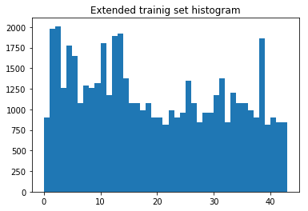

```python
binwidth = 1
plt.hist(y_train, bins=range(0, n_classes + binwidth, binwidth))
plt.title('Extended trainig set histogram')
plt.show()
```

### Pre-process the Data Set

Minimally, the image data should be normalized so that the data has mean zero and equal variance. For image data, `(pixel - 128)/ 128` is a quick way to approximately normalize the data and can be used in this project.

Other pre-processing steps are optional. You can try different techniques to see if it improves performance.

Use the code cell (or multiple code cells, if necessary) to implement the first step of your project.

```python
### Normalize the data and convert to grayscale (there are no signs which are differ only by color)
import cv2

def normalize(darray_img):
    img = darray_img.astype(np.float) # cast to float
    img = np.divide((img - 128.0), 128.0)
    return img

def rgb2gray(rgb):
    return cv2.cvtColor(rgb, cv2.COLOR_RGB2GRAY)
    #return np.dot(rgb[...,:3], [0.2989, 0.5870, 0.1140])
```

```python
X_train_norm_gray = np.empty(X_train.shape[0:3])
X_test_norm_gray = np.empty(X_test.shape[0:3])
X_valid_norm_gray = np.empty(X_valid.shape[0:3])

for i in range(X_train.shape[0]):
    gray_arr = rgb2gray(X_train[i])
    X_train_norm_gray[i] = normalize(gray_arr)
X_train = np.expand_dims(X_train_norm_gray, axis=3)

for i in range(X_test.shape[0]):
    gray_arr = rgb2gray(X_test[i])
    X_test_norm_gray[i] = normalize(gray_arr)
X_test = np.expand_dims(X_test_norm_gray, axis=3)

for i in range(X_valid.shape[0]):
    gray_arr = rgb2gray(X_valid[i])
    X_valid_norm_gray[i] = normalize(gray_arr)
X_valid = np.expand_dims(X_valid_norm_gray, axis=3)
```

### Model Architecture

[figure not shown]

The model architecture is similar to **Lenet**. It has three convolutional layers and three fully connected layers.

| Layer | Description |
| --- | --- |
| Input | 32x32x1 Grayscale image |
| Convolution 5x5 | 1x1 stride, 'SAME' padding, output 32x32x32, Leaky ReLU |
| Max pooling | window size 2, output 16x16x32 |
| Convolution 5x5 | 1x1 stride, 'SAME' padding, output 16x16x64, Leaky ReLU |
| Max pooling | window size 2, output 8x8x64 |
| Convolution 5x5 | 1x1 stride, 'SAME' padding, output 8x8x128, Leaky ReLU |
| Max pooling | window size 2, output 4x4x128 |
| Fully connected | Input 2048, output 1024, Leaky ReLU |
| Dropout | Drop rate 0.5 |
| Fully connected | Input 1024, output 340, Leaky ReLU |
| Dropout | Drop rate 0.5 |
| Fully connected | Input 340, output 43 |
| Softmax |  |

```python
import tensorflow as tf

def max_pool(conv_x, size, name='max_pool', padding = 'SAME'):
    return tf.nn.max_pool(
        conv_x,
        ksize = [1, size, size, 1],
        strides = [1, size, size, 1],
        padding = padding,
        name = name
    )
```

```python
from tensorflow.contrib.layers import flatten

def TrafficSignsNet(features, dropout_rate, is_training):
    # Arguments used for tf.truncated_normal, randomly defines variables for the weights and biases for each layer
    mu = 0
    sigma = 0.1
    alpha = 0.01 # leaky ReLU parameter
    padding = 'SAME'

    ##############################################################################################
    # Layer 1: Convolutional. Input = 32x32x1. Output = 32x32x32.
    conv1_K = 32
    conv1_W = tf.Variable(tf.truncated_normal(shape=(5, 5, 1, conv1_K), mean = mu, stddev = sigma))
    conv1_b = tf.Variable(tf.zeros(conv1_K))
    conv1   = tf.nn.conv2d(features, conv1_W, strides=[1, 1, 1, 1], padding=padding) + conv1_b

    # Activation. Leaky ReLU
    conv1 = tf.nn.leaky_relu(conv1, alpha)


    # Max Pooling. Input = 32x32x32. Output = 16x16x32.
    conv1 = max_pool(conv1, 2, name='conv1', padding=padding)

    ##############################################################################################
    # Layer 2: Convolutional. Input = 16x16x32 Output = 16x16x64.
    conv2_K = 64
    conv2_W = tf.Variable(tf.truncated_normal(shape=(5, 5, conv1_K, conv2_K), mean = mu, stddev = sigma))
    conv2_b = tf.Variable(tf.zeros(conv2_K))
    conv2   = tf.nn.conv2d(conv1, conv2_W, strides=[1, 1, 1, 1], padding=padding) + conv2_b

    # Activation. Leaky ReLU
    conv2 = tf.nn.leaky_relu(conv2, alpha)


    # Max Pooling. Input = 16x16x64. Output = 8x8x64.
    conv2 = max_pool(conv2, 2, name='conv2', padding=padding)

    ##############################################################################################
    # Layer 3: Convolutional. Input = 8x8x64 Output = 8x8x128.
    conv3_K = 128
    conv3_W = tf.Variable(tf.truncated_normal(shape=(5, 5, conv2_K, conv3_K), mean = mu, stddev = sigma))
    conv3_b = tf.Variable(tf.zeros(conv3_K))
    conv3   = tf.nn.conv2d(conv2, conv3_W, strides=[1, 1, 1, 1], padding=padding) + conv3_b

    # Activation. Leaky ReLU
    conv3 = tf.nn.leaky_relu(conv3, alpha)

    # Max Pooling. Input = 8x8x128. Output = 4x4x128.
    conv3 = max_pool(conv3, 2, name='conv3', padding=padding)

    ##############################################################################################
    # Flatten. Input = 4x4x128. Output = 2048.
    fc0   = flatten(conv3)
    fc0_out = fc0.get_shape().as_list()[1]

    ##############################################################################################
    # Layer 4: Fully Connected. Input = 2048. Output = 1024.
    fc1_out = 1024
    fc1_W = tf.Variable(tf.truncated_normal(shape=(fc0_out, fc1_out), mean = mu, stddev = sigma))
    fc1_b = tf.Variable(tf.zeros(fc1_out))

    fc1 = tf.add(tf.matmul(fc0, fc1_W), fc1_b, name='fc1')

    # Activation.
    fc1    = tf.nn.leaky_relu(fc1, alpha)
    # Dropout
    fc1 = tf.layers.dropout(inputs=fc1, rate=dropout_rate, training=is_training)

    # Layer 5: Fully Connected. Input = 1024. Output = 340.
    fc2_out = 340
    fc2_W = tf.Variable(tf.truncated_normal(shape=(fc1_out, fc2_out), mean = mu, stddev = sigma))
    fc2_b = tf.Variable(tf.zeros(fc2_out))

    fc2 = tf.add(tf.matmul(fc1, fc2_W), fc2_b, name='fc2')

    # Activation.
    fc2    = tf.nn.leaky_relu(fc2, alpha)
    # Dropout
    fc2 = tf.layers.dropout(inputs=fc2, rate=dropout_rate, training=is_training)

    ##############################################################################################
    # Layer 6: Fully Connected. Input = 340. Output = 43.
    fc3_out = 43
    fc3_W  = tf.Variable(tf.truncated_normal(shape=(fc2_out, fc3_out), mean = mu, stddev = sigma))
    fc3_b  = tf.Variable(tf.zeros(fc3_out))

    logits = tf.add(tf.matmul(fc2, fc3_W), fc3_b, name='fc3')

    return logits
```

`x` is a placeholder for a batch of input images.  
`y` is a placeholder for a batch of output labels.  
`drop_rate` is a dropout rate, between 0 and 1. E.g. "rate=0.1" would drop out 10% of input units.  
`is_training` indicates whether to return the output in training mode (apply dropout) or in inference mode (return the input untouched).

```python
x = tf.placeholder(tf.float32, (None, 32, 32, 1))
y = tf.placeholder(tf.int32, (None))
drop_rate = tf.placeholder(tf.float32)
is_training = tf.placeholder(tf.bool)

one_hot_y = tf.one_hot(y, n_classes)
logits = TrafficSignsNet(x, drop_rate, is_training)
cross_entropy = tf.nn.softmax_cross_entropy_with_logits_v2(labels=one_hot_y, logits=logits)
```

`learn_rate` is one of the most important hyperparameters. Decides 'how rough' the weights are updated during training.

```python
learn_rate = 0.001
```

**The Adam optimization algorithm** is an extension to stochastic gradient descent. Its one of the most used optimization algorithms.

```python
loss_operation = tf.reduce_mean(cross_entropy)
optimizer = tf.train.AdamOptimizer(learning_rate = learn_rate)
training_operation = optimizer.minimize(loss_operation)
```

### Train, Validate and Test the Model

A validation set can be used to assess how well the model is performing. A low accuracy on the training and validation sets imply underfitting. A high accuracy on the training set but low accuracy on the validation set implies overfitting.

```python
correct_prediction = tf.equal(tf.argmax(logits, 1), tf.argmax(one_hot_y, 1))
accuracy_operation = tf.reduce_mean(tf.cast(correct_prediction, tf.float32))
saver = tf.train.Saver()

def evaluate(X_data, y_data):
    num_examples = len(X_data)
    total_accuracy = 0
    sess = tf.get_default_session()
    for offset in range(0, num_examples, BATCH_SIZE):
        batch_x, batch_y = X_data[offset:offset+BATCH_SIZE], y_data[offset:offset+BATCH_SIZE]
        accuracy = sess.run(accuracy_operation, feed_dict={x: batch_x, y: batch_y, drop_rate: 0.0, is_training: False})
        total_accuracy += (accuracy * len(batch_x))
    return total_accuracy / num_examples
```

```python
from sklearn.utils import shuffle

EPOCHS = 40
BATCH_SIZE = 128 # how many training images to run through the network at a time

dropout = 0.5
dropout_rate = 1 - dropout
```

```python
validation_accuracy_list = []

with tf.Session() as sess:
    sess.run(tf.global_variables_initializer())
    num_examples = len(X_train)

    print("Training...")
    print()
    for i in range(EPOCHS):
        X_train, y_train = shuffle(X_train, y_train)
        for offset in range(0, num_examples, BATCH_SIZE):
            end = offset + BATCH_SIZE
            batch_x, batch_y = X_train[offset:end], y_train[offset:end]
            sess.run(training_operation, feed_dict={x: batch_x, y: batch_y, drop_rate: dropout_rate, is_training: True})

        validation_accuracy = evaluate(X_valid, y_valid)
        validation_accuracy_list.append(validation_accuracy)

        print("EPOCH {} ...".format(i+1))
        print("Validation Accuracy = {:.3f}".format(validation_accuracy))
        print()

    saver.save(sess, './traffic_signs_net')
    print("Model saved")
```

```
Training...

EPOCH 1 ...
Validation Accuracy = 0.621

EPOCH 2 ...
Validation Accuracy = 0.869

EPOCH 3 ...
Validation Accuracy = 0.911

EPOCH 4 ...
Validation Accuracy = 0.915

EPOCH 5 ...
Validation Accuracy = 0.933

EPOCH 6 ...
Validation Accuracy = 0.933

EPOCH 7 ...
Validation Accuracy = 0.939

EPOCH 8 ...
Validation Accuracy = 0.937

EPOCH 9 ...
Validation Accuracy = 0.945

EPOCH 10 ...
Validation Accuracy = 0.951

EPOCH 11 ...
Validation Accuracy = 0.944

EPOCH 12 ...
Validation Accuracy = 0.947

EPOCH 13 ...
Validation Accuracy = 0.944
```

[output cut: 68 more lines]

```
Validation Accuracy = 0.967

EPOCH 37 ...
Validation Accuracy = 0.946

EPOCH 38 ...
Validation Accuracy = 0.960

EPOCH 39 ...
Validation Accuracy = 0.963

EPOCH 40 ...
Validation Accuracy = 0.966

Model saved
```

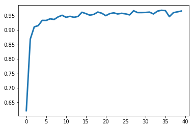

```python
import matplotlib.pyplot as plt
# Visualizations will be shown in the notebook.
%matplotlib inline

plt.plot(range(len(validation_accuracy_list)), validation_accuracy_list, linewidth = 3)
```

## Step 3: Test a Model on New Images

To give yourself more insight into how your model is working, download at least five pictures of German traffic signs from the web and use your model to predict the traffic sign type.

You may find `signnames.csv` useful as it contains mappings from the class id (integer) to the actual sign name.

### Load and Output the Images

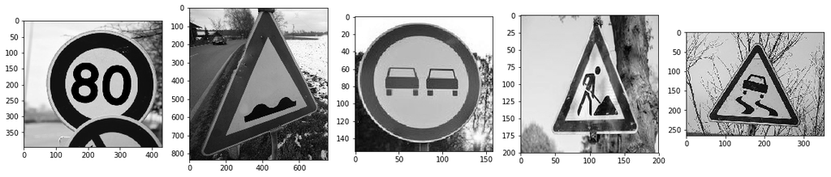

```python
### Load the images and plot them here.
import numpy as np
import cv2
import glob

import matplotlib.pyplot as plt
# Visualizations will be shown in the notebook.
%matplotlib inline

fig, axes = plt.subplots(
ncols=5,
nrows=1,
figsize=(20, 10))

images_names = glob.glob('test_images/*.jpg')
test_images = []

for ax, fname in zip(axes.flat, images_names):
    img = cv2.imread(fname)
    #normalizedImg = np.zeros((32, 32, 1))
    #img_norm = cv2.normalize(cv2.cvtColor(img, cv2.COLOR_RGB2GRAY),  normalizedImg, 0, 1, cv2.NORM_MINMAX)
    img_norm = normalize(cv2.cvtColor(img, cv2.COLOR_RGB2GRAY))
    ax.imshow(img_norm, cmap='gray',clim=(-1,1))
    resized = cv2.resize(img_norm, (32,32), interpolation=cv2.INTER_AREA)
    test_images.append(resized)

plt.show()

test_images = np.array(test_images)
test_images = np.expand_dims(test_images, axis=3)
# Speed limit (80km/h); Bumpy road; No passing; Road work; Slippery road
test_labels = [5, 22, 9, 25, 23]
```

```python
softmax_logits = tf.nn.softmax(logits)
classifier = tf.argmax(softmax_logits, axis = 1) # Determine class ID of highest probability

with tf.Session() as sess:
    sess.run(tf.global_variables_initializer())
    saver = tf.train.import_meta_graph('traffic_signs_net.meta')
    saver.restore(sess, "traffic_signs_net")
    predict = sess.run(classifier, feed_dict={x: test_images, y: test_labels, drop_rate: 0, is_training: False})
    print("")
    print("Predicted labels are: ", predict)
    print("Correct labels are: ", test_labels)
```

```
INFO:tensorflow:Restoring parameters from traffic_signs_net

Predicted labels are:  [ 5 22  9 25 23]
Correct labels are:  [5, 22, 9, 25, 23]
```

### Predict the Sign Type for Each Image

```python
### Run the predictions here and use the model to output the prediction for each image.
### Make sure to pre-process the images with the same pre-processing pipeline used earlier.
### Feel free to use as many code cells as needed.

with tf.Session() as sess:
    saver.restore(sess, tf.train.latest_checkpoint('.'))

    test_accuracy = evaluate(X_test, y_test)
    print("Test Accuracy = {:.3f}".format(test_accuracy))
```

```
INFO:tensorflow:Restoring parameters from .\traffic_signs_net
Test Accuracy = 0.950
```

### Output Top 5 Softmax Probabilities For Each Image Found on the Web

For each of the new images, print out the model's softmax probabilities to show the **certainty** of the model's predictions (limit the output to the top 5 probabilities for each image). [`tf.nn.top_k`](https://www.tensorflow.org/versions/r0.12/api_docs/python/nn.html#top_k) could prove helpful here.

The example below demonstrates how tf.nn.top_k can be used to find the top k predictions for each image.

`tf.nn.top_k` will return the values and indices (class ids) of the top k predictions. So if k=3, for each sign, it'll return the 3 largest probabilities (out of a possible 43) and the correspoding class ids.

```python
### Print out the top five softmax probabilities for the predictions on the German traffic sign images found on the web.
### Feel free to use as many code cells as needed.
top_5 = tf.nn.top_k(softmax_logits, k=5)

with tf.Session() as sess:
    sess.run(tf.global_variables_initializer())
    saver = tf.train.import_meta_graph('traffic_signs_net.meta')
    saver.restore(sess, "traffic_signs_net")
    probability_5 = sess.run(top_5, feed_dict={x: test_images, drop_rate: 0, is_training: False})
```

```
INFO:tensorflow:Restoring parameters from traffic_signs_net
```

All signs were classified correctly.

[output not shown]

| Idx | Description | Probability | --- | Idx | Description | Probability |
| --- | --- | --- | --- | --- | --- | --- |
| 25 | **Road work** | 1.0000000e+00 | --- | 23 | **Slippery road** | 9.9994075e-01 |
| 18 | General caution | 9.5928652e-17 | --- | 30 | Beware of ice/snow | 5.9071997e-05 |
| 11 | Right-of-way at the next intersection | 1.0563458e-18 | --- | 21 | Double curve | 1.2561594e-07 |
| 30 | Beware of ice/snow | 3.1563438e-22 | --- | 19 | Dangerous curve to the left | 3.5005552e-08 |
| 20 | Dangerous curve to the right | 1.9739832e-23 | --- | 10 | No passing for vehicles over 3.5 metric tons | 4.1987342e-09 |

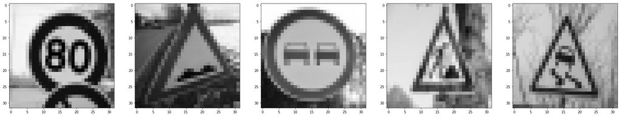

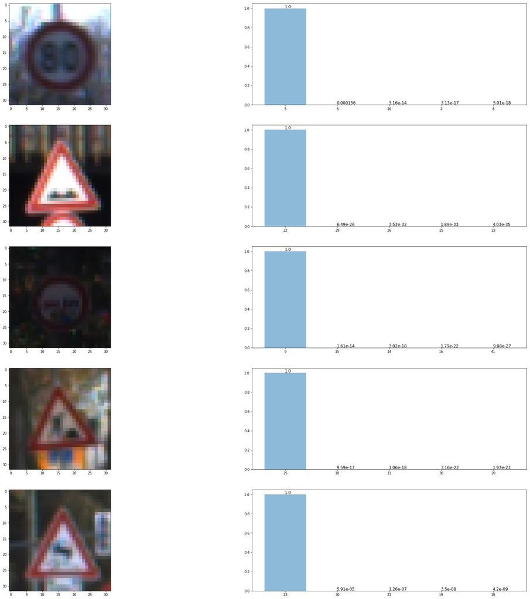

```python
N = 5


fig_img, axes_img = plt.subplots(
ncols=N,
nrows=1,
figsize=(32, 32))

for ax, img in zip(axes_img.flat, test_images):
    ax.imshow(img[:, :, 0], cmap='gray',clim=(-1,1))

plt.show()


fig, axes = plt.subplots(
    ncols=2,
    nrows=N,
    figsize=(32, 32))

axes = axes.ravel()

ax_id = 0
for i in range(N):

    img_id = probability_5[1][i][0]
    axes[ax_id].imshow(image_examples[img_id])

    ax_id = ax_id + 1
    axes[ax_id].bar(range(N), probability_5[0][i], align='center', alpha=0.5)
    axes[ax_id].set_xticks(range(N))
    axes[ax_id].set_xticklabels(probability_5[1][i])

    # Text on the top of each barplot
    for j in range(N):
        val = probability_5[0][i][j]
        val = float("{0:1.2e}".format(val))
        axes[ax_id].text(x = j-0.01, y = val+0.005, s = val, size = 12)

    ax_id = ax_id + 1

plt.show()
```

### Reflection

The main parts of the task were:

- random image generator for training database extension;
- design and implement the network architecture;
- tune hyperparameters.

For designed network following hyperparameters had to be set:

- learning rate : 0.001
- drop rate : 0.5
- batch size : 128
- epochs : 40

Also:

- type of padding : 'SAME'
- stride : 1
- convolution filter size : 5x5
- size of intermediate fully connected layers: 1024, 340
- coefficient for leaky ReLU : 0.01
- pooling strategy : max pooling

Deep neural network learning process requires a lot of tuning hyperparameters. Due to high level of freedom it's almost impossible to manully try all combinations. In further research it would be interesting to try Hyperopt functionality, although it requires a lot of computational power.

Also an interesting observation: Many articles recommend to replace dropout by batch normalization. Or add batch normalization between every convolutional layer before or after pooling. In this case it gave worse results: 0.3 after 5th epoch. Drop out gave us 0.933 after 5th epoch.

## Step 4 (Optional): Visualize the Neural Network's State with Test Images

This Section is not required to complete but acts as an additional excersise for understaning the output of a neural network's weights. While neural networks can be a great learning device they are often referred to as a black box. We can understand what the weights of a neural network look like better by plotting their feature maps. After successfully training your neural network you can see what it's feature maps look like by plotting the output of the network's weight layers in response to a test stimuli image. From these plotted feature maps, it's possible to see what characteristics of an image the network finds interesting. For a sign, maybe the inner network feature maps react with high activation to the sign's boundary outline or to the contrast in the sign's painted symbol.

Provided for you below is the function code that allows you to get the visualization output of any tensorflow weight layer you want. The inputs to the function should be a stimuli image, one used during training or a new one you provided, and then the tensorflow variable name that represents the layer's state during the training process, for instance if you wanted to see what the LeNet lab's feature maps looked like for it's second convolutional layer you could enter conv2 as the tf_activation variable.

For an example of what feature map outputs look like, check out NVIDIA's results in their paper [End-to-End Deep Learning for Self-Driving Cars](https://devblogs.nvidia.com/parallelforall/deep-learning-self-driving-cars/) in the section Visualization of internal CNN State. NVIDIA was able to show that their network's inner weights had high activations to road boundary lines by comparing feature maps from an image with a clear path to one without. Try experimenting with a similar test to show that your trained network's weights are looking for interesting features, whether it's looking at differences in feature maps from images with or without a sign, or even what feature maps look like in a trained network vs a completely untrained one on the same sign image.

```python
### Visualize your network's feature maps here.
### Feel free to use as many code cells as needed.

# image_input: the test image being fed into the network to produce the feature maps
# tf_activation: should be a tf variable name used during your training procedure that represents the calculated state of a specific weight layer
# activation_min/max: can be used to view the activation contrast in more detail, by default matplot sets min and max to the actual min and max values of the output
# plt_num: used to plot out multiple different weight feature map sets on the same block, just extend the plt number for each new feature map entry

def outputFeatureMap(image_input, tf_activation, activation_min=-1, activation_max=-1 ,plt_num=1):
    # Here make sure to preprocess your image_input in a way your network expects
    # with size, normalization, ect if needed
    # image_input =
    # Note: x should be the same name as your network's tensorflow data placeholder variable
    # If you get an error tf_activation is not defined it may be having trouble accessing the variable from inside a function
    activation = tf_activation.eval(session=sess,feed_dict={x : image_input})
    featuremaps = activation.shape[3]
    plt.figure(plt_num, figsize=(15,15))
    cols_num = 6
    rows_num = math.ceil(featuremaps / cols_num)
    for featuremap in range(featuremaps):
        plt.subplot(rows_num, cols_num, featuremap+1) # sets the number of feature maps to show on each row and column
        plt.title('FeatureMap ' + str(featuremap)) # displays the feature map number
        if activation_min != -1 & activation_max != -1:
            plt.imshow(activation[0,:,:, featuremap], interpolation="nearest", vmin =activation_min, vmax=activation_max, cmap="gray")
        elif activation_max != -1:
            plt.imshow(activation[0,:,:, featuremap], interpolation="nearest", vmax=activation_max, cmap="gray")
        elif activation_min !=-1:
            plt.imshow(activation[0,:,:, featuremap], interpolation="nearest", vmin=activation_min, cmap="gray")
        else:
            plt.imshow(activation[0,:,:, featuremap], interpolation="nearest", cmap="gray")
```

**1st convolutional layer**

```
INFO:tensorflow:Restoring parameters from traffic_signs_net
```

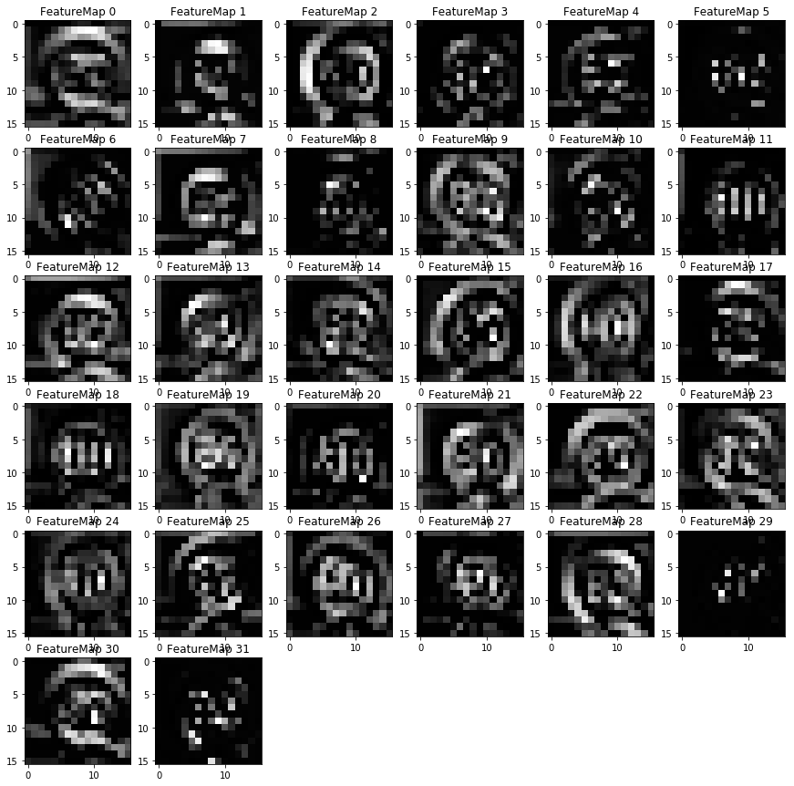

```python
import tensorflow as tf

test_img = test_images[:1,:,:,:]

with tf.Session() as sess:
    sess.run(tf.global_variables_initializer())
    saver = tf.train.import_meta_graph('traffic_signs_net.meta')
    saver.restore(sess, "traffic_signs_net")

    conv1 = sess.graph.get_tensor_by_name('conv1:0')
    outputFeatureMap(test_img, conv1)
    plt.show()
```

```
INFO:tensorflow:Restoring parameters from traffic_signs_net
```

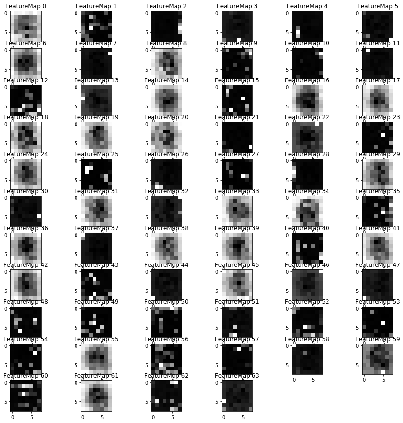

```python
with tf.Session() as sess:
    sess.run(tf.global_variables_initializer())
    saver = tf.train.import_meta_graph('traffic_signs_net.meta')
    saver.restore(sess, "traffic_signs_net")

    conv2 = sess.graph.get_tensor_by_name('conv2:0')
    outputFeatureMap(test_img, conv2)
    plt.show()
```